# 3 – Univariate Analysis

## Quantitative variables

Some basic functions for univariate analysis on a quantitative variable.

```r
# Lengths superheroes
lengths <- c(141, 198, 143, 201, 184)
```

### Measures of central tendency

```r
mean(lengths)                     # mean or average
```

```
## [1] 173.4
```

```r
median(lengths)
```

```
## [1] 184
```

### Measures of dispersion

```r
range(lengths)                    # minimum & maximum
```

```
## [1] 141 201
```

```r
abs(max(lengths) - min(lengths))  # range
```

```
## [1] 60
```

```r
summary(lengths)                  # Quartiles, etc.
```

```
##    Min. 1st Qu.  Median    Mean 3rd Qu.    Max.
##   141.0   143.0   184.0   173.4   198.0   201.0
```

```r
IQR(lengths)                      # Interquartile range
```

```
## [1] 55
```

```r
sd(lengths)                       # standard deviation of a *sample*
```

```
## [1] 29.38197
```

### Formula breakdown

Mathematical formulae can often be translated to R quite straightforwardly. Take e.g. the formula for the mean:

$\mu = \frac{\sum_{x=1}^{n}x_i}{n}$

In R, this becomes:

```r
sum(lengths) / length(lengths)
```

```
## [1] 173.4
```

The same goes for the variance and standard deviation. In the example below, we use the definition of population variance (denominator $n$).

$\sigma^2 = \frac{\sum_{i=1}^{n} \left(x_{i} - \mu\right)^2}{n}$

In the code below, we break down the formula in parts:

```r
res_1 <- lengths - mean(lengths)    # difference of data points with mean
res_2 <- res_1^2                    # squared differences
res_3 <- sum(res_2)                 # take the sum
variance <- res_3 / length(lengths) # calculate average
stdev <- sqrt(variance)             # take the square root
```

Or, the entire calculation of variance in one formula. Can you recognize the mathematical formula in the R-code?

```r
variance <- sum((lengths - mean(lengths))^2) / length(lengths)
```

### Calculations by group

Often, you want to get calculations of mean, standard deviation, etc. grouped by some factor. This can be done using the `aggregate` function, and the “group by” `~` operator.

We show some examples from the `mtcars` dataset.

```r
View(mtcars)
# Show the average mileage per gallon for cars with and
# without an automatic transmission.
aggregate(mpg ~ am, data = mtcars, FUN = mean)
```

```
##   am      mpg
## 1  0 17.14737
## 2  1 24.39231
```

```r
# Standard deviation
aggregate(mpg ~ am, data = mtcars, FUN = sd)
```

```
##   am      mpg
## 1  0 3.833966
## 2  1 6.166504
```

```r
# Apply the summary function
aggregate(mpg ~ am, data = mtcars, FUN = summary)
```

```
##   am mpg.Min. mpg.1st Qu. mpg.Median mpg.Mean mpg.3rd Qu. mpg.Max.
## 1  0 10.40000    14.95000   17.30000 17.14737    19.20000 24.40000
## 2  1 15.00000    21.00000   22.80000 24.39231    30.40000 33.90000
```

Remark that the `data` parameter allows you to reference the column names directly, instead of having to use the notation `mtcars$mpg ~ mtcars$am`.

## Qualitative variables

In R, qualitative variables are called *factors*. As an example, we’ll use the `esoph` dataset from the `datasets` package, available in R.

```r
?esoph
```

```
## starting httpd help server ... done
```

```r
View(esoph)
```

### Measures of central tendency

About the only measure of central tendency for a factor/qualitative variable is the mode. There is no actual mode function in R, but you can find it in several ways. The first is to print a frequency table and read the maximum from there:

```r
levels(esoph$agegp)            # Show all values of the variable
```

```
## [1] "25-34" "35-44" "45-54" "55-64" "65-74" "75+"
```

```r
freq_tab <- table(esoph$agegp) # Calculate a frequency table
freq_tab
```

```
##
## 25-34 35-44 45-54 55-64 65-74   75+
##    15    15    16    16    15    11
```

```r
summary(esoph$agegp)           # The summary function applied to a factor
```

```
## 25-34 35-44 45-54 55-64 65-74   75+
##    15    15    16    16    15    11
```

The output of both `table` and `summary` (applied to a factor) is identical.

From there, we could look for the value that occurs the most:

```r
which.max(table(esoph$agegp)) # Only works for the case with a single mode
```

```
## 45-54
##     3
```

```r
names(freq_tab)[freq_tab == max(freq_tab)] # Also works for multimodal variables
```

```
## [1] "45-54" "55-64"
```

## Charts in R

For univariate statistics, the most common chart types are:

- **boxplot**, that shows the spread of a (quantitative)
- **bar chart**, which can be used for
  - showing the values of a quantitative variable
  - showing the frequencies of a qualitative variable
- **histogram**, a variant of the bar chart for frequencies, where ranges of x-values are taken together in “buckets”

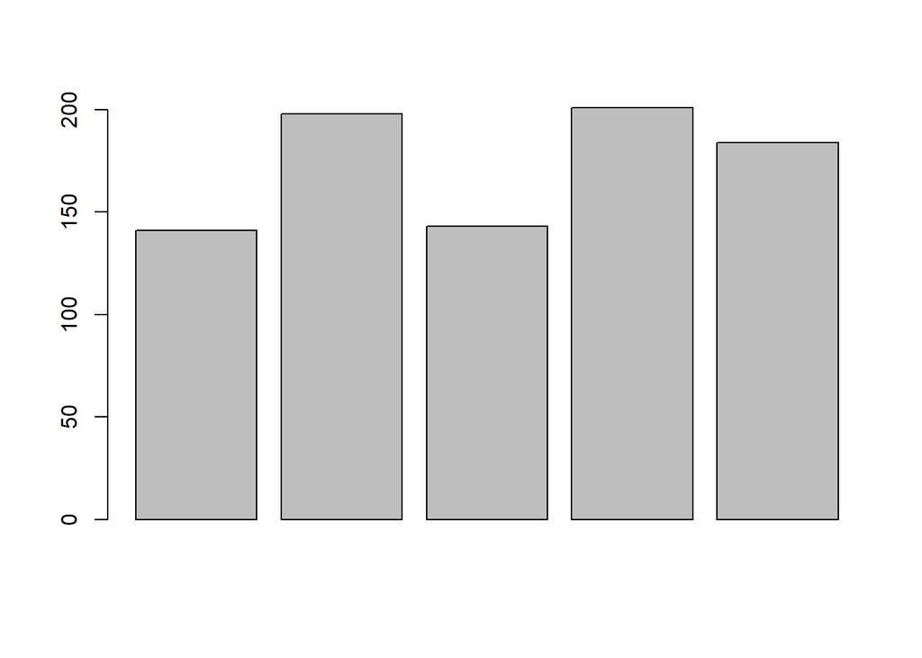

```r
# Chart types
barplot(lengths)  # bar chart (without any fancy layout add-ons)
```

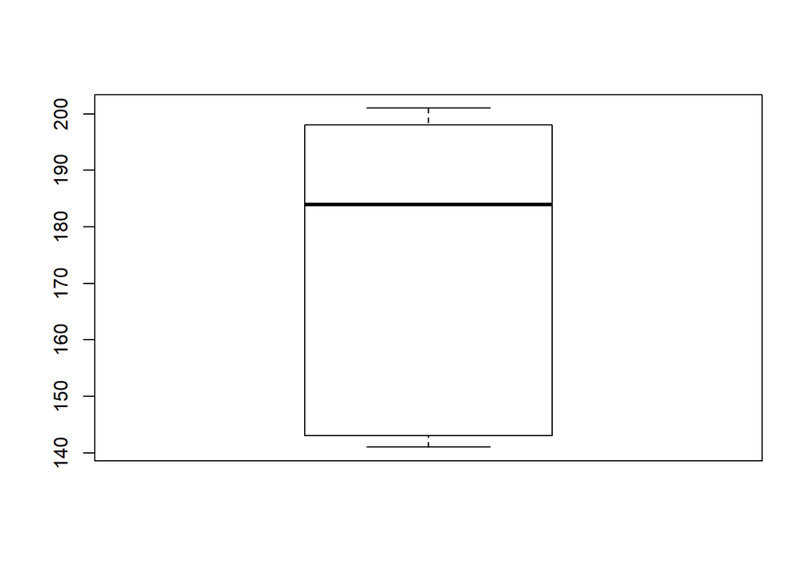

```r
boxplot(lengths)  # boxplot
```

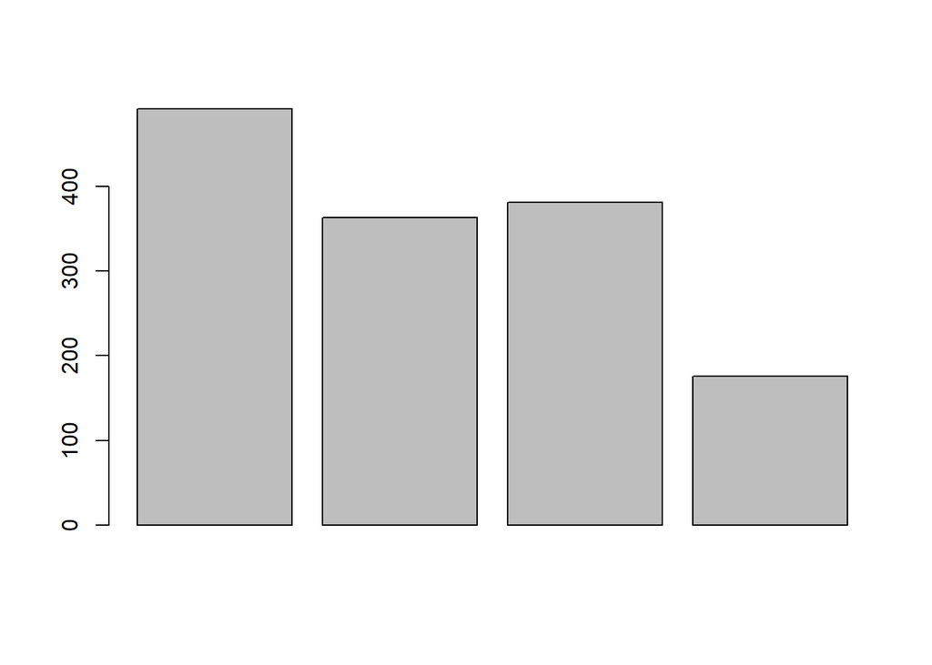

```r
# Example "Active Duty Personnel, 1998"
active_duty_personnel <- c(492, 363, 381, 176)

barplot(active_duty_personnel)
```

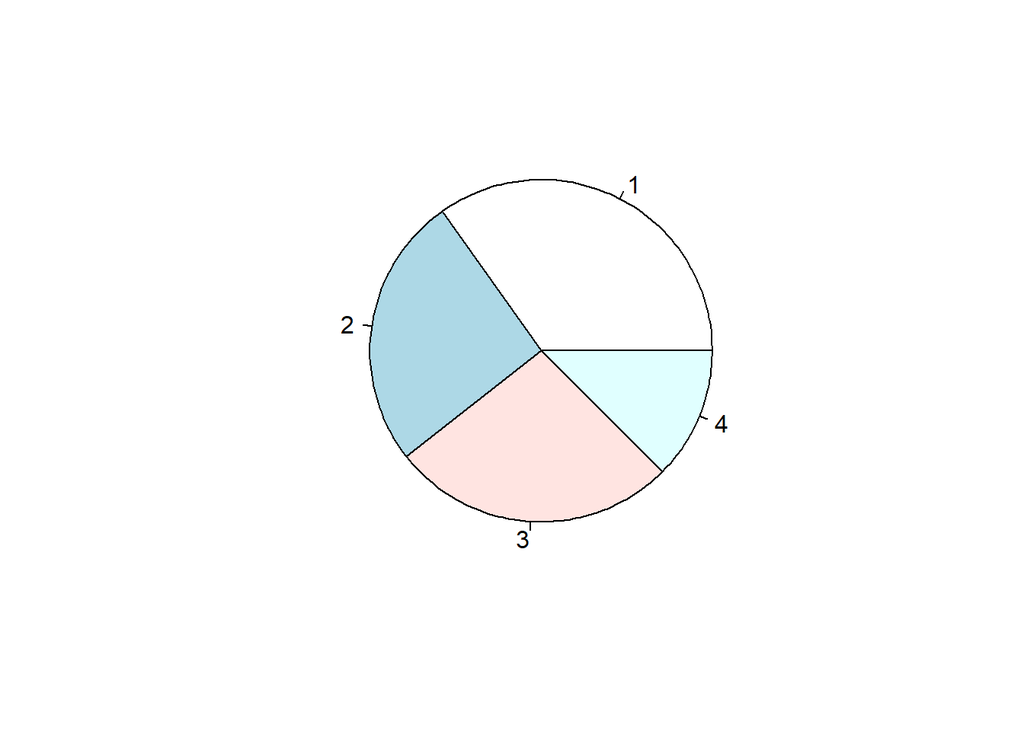

```r
pie(active_duty_personnel)       # Shown for reference, avoid pie charts!
```

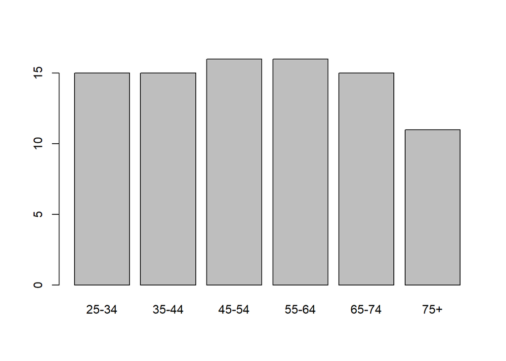

```r
# Plot of the frequencies of a qualitative variable
barplot(table(esoph$agegp))
```

As an example of a histogram, we take the `cars` dataset as an example.

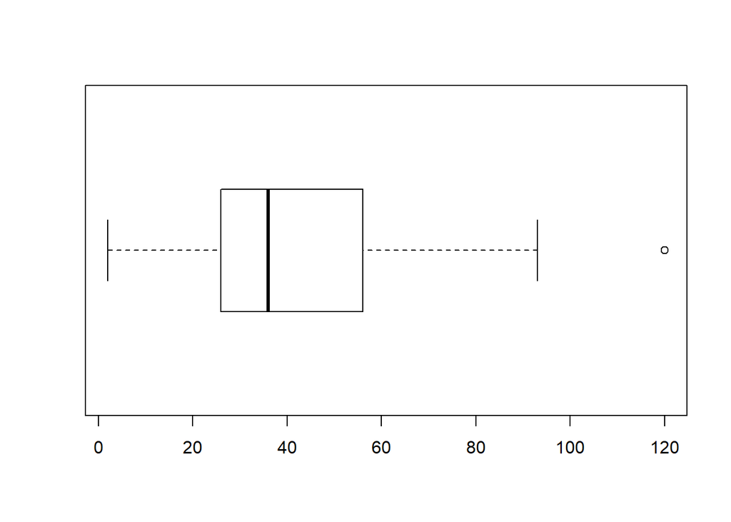

```r
# For reference, a boxplot of the data
boxplot(cars$dist, horizontal = TRUE)
```